# Web Scraping in Python

Hari Patchigolla

8/1/2022

# Table of Contents

1. Introduction to Web Scraping
   - What is Web Scraping?
   - Data Science Pipeline
     - Where does Web Scraping fit in the Data Science Pipeline?
2. `Requests` and `BeautifulSoup`
   - How does Web Scraping work?
   - Static Web Scraping with `BeautifulSoup`
     - Scraping MLS data
3. `Selenium` and SQL (sqlite3)
   - How to create web scraping bots
   - Storing scraped data in an SQL database
4. Legality of Web Scraping
   - When is it okay to Scrape a website
     - Consequences of scraping a website you are not allowed to scrape
   - Easy ways to know if a website is okay to scrape
     - `/robots.txt`
     - How to read a `robots.txt` file

# Introduction to Web Scraping

# What is Web Scraping?

- A method of extracting data from a webpage
  - Data is stored in HTML

[figure not shown]

HTML document of Yordan Alvarez’s stats

- Notice that all visible information can be located somewhere in the HTML document
  - Web scraping takes advantage if this by located this information ina webpage

# Data Science Pipeline

[figure not shown]

The Data Science Pipeline

- Where does Web Scraping fit in the Data Science Pipeline?
  - Built in Data sets
    - Sci-kit Learn
    - R packages
  - Data sets Online
    - Kaggle
    - Government sites
- Data is Everywhere
  - We can make out own datasets

# `Requests` and `BeautifulSoup`

[figure not shown]

`requests`

- The `requests` library is used to make HTTP requests in Python
  - Can be used to get the HTML document/content of a webpage

[figure not shown]

`BeautifulSoup`

- The `BeautifulSoup` library is used to parse through HTML documents
  - Can locate specific parts of a webpage (useful for extracting data)

# Web Scraping Pipeline

1. Use the `requests` library to make an HTTP GET request
   - This GET request will return the HTML content of a webpage
2. Parse through the HTML and extract specific data with the `BeautifulSoup` package
   - Use CSS Selectors for identifying and extract these specific parts of the HTML document
3. Store the data
   - We will be using the `pandas` package in this presentation

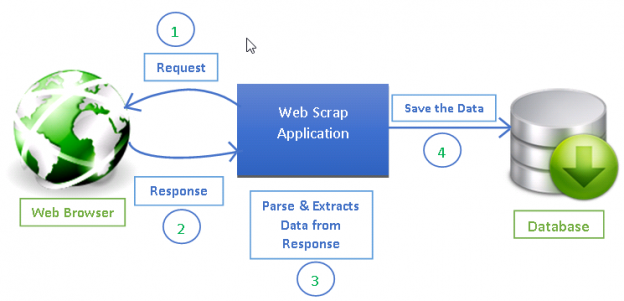

Web Scraping Pipeline

**DEMO**

# `Selenium` and SQL (sqlite3)

- `Selenium` is used to interact with webpages via creating bots
- Allows use to dymanically scrape data

[figure not shown]

Selenium

- SQL (Structured Query Language)
  - A lot of data is stored in databases, SQL allows us to interact with this data

**DEMO**

# Legality of Web Scraping

- Scraping publicly available data (for the most part) is safe
  - Government sites, or other data without restricted access
- Sometimes “public” data is not legal to web scrape
  - [Intel Corp. v. Hamidi](https://en.wikipedia.org/wiki/Intel_Corp._v._Hamidi)
  - [Meta Files Two Lawsuits Over Illicit Data Scraping from Facebook and Instagram](https://www.spiceworks.com/tech/tech-general/news/meta-sues-for-data-scraping/)
  - [Supreme Court Grants Certiorari in Web Scraping Case hiQ v. LinkedIn](https://www.lowenstein.com/news-insights/publications/client-alerts/supreme-court-grants-certiorari-in-web-scraping-case-hiq-v-linkedin-tech-groupwhite-collar)
- What is a easy way to tell if you can or cannot scrape a certain website
  - `/robots.txt` file

https://www.nfl.com/robots.txt  
https://www.spotrac.com/robots.txt  
https://www.linkedin.com/robots.txt  
https://facebook.com/robots.txt

**DEMO**